# Ford GoBike tripdata analysis

## by Rayan Alharbi

## Investigation Overview

> I want to explore the different variables that this dataset offers and also identify if there are any realtions or insight to be uncovered

## Dataset Overview

> the Ford GoBike trip dataset has 170883 rows and 22 columns, such as duration of trip and user ages and type, also weekdays of trips and times of day and other variables that I will be exploring shortly

## Distribution of ages

> Most ages of users are from 25-40 and Distribution is right skewed

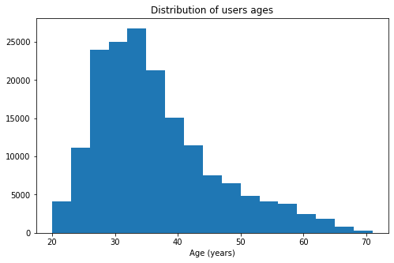

## Distribution of trips across weekdays

> most rides are through the work days where the number of rides in the weekends decreases

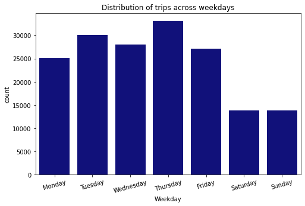

## Distribution of trips across different time of the data

> Most rides are in the mornings and then in the evening and after noon, with fewer bike rides in the night, this can be the result of users using bikes commute to work

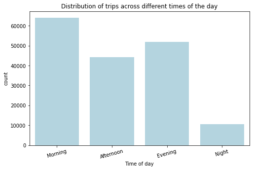

## Duration of trips for different user types

> the box plot shows that the median duration time of customer's trips is higher than the median of the subscribers trips

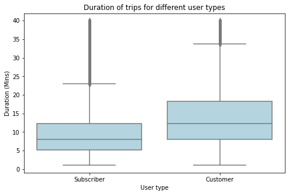

## Average duration across weekdays

> the line plot shows that duration of rides on weekends is higher than the duration throug the workdays, I think this can people are busier on work days and don't want to be late, but on weekends they can take their time

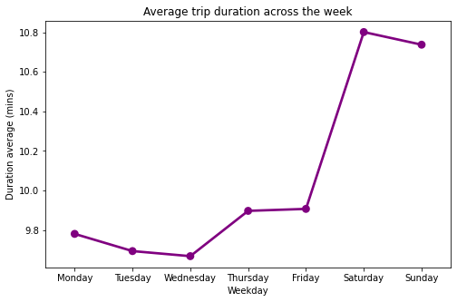

## Average users ages across the week

> we can see that average age on workdays is higher than the average age on weekends!

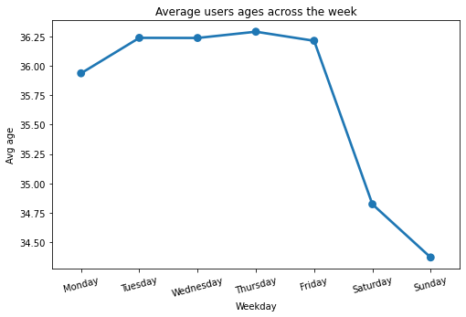

## Distribution of trips times on different weekdays

> we can see that for all workdays the most common trip times are Morning and Evening but on weekends these two time decreases and trips on the Afternoon increases, again I think this is the result of most people using the bikes to commute to work

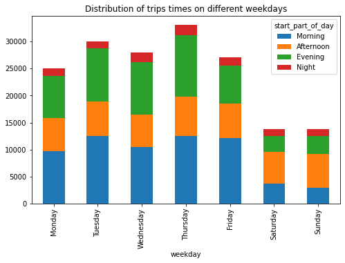

## Average duration time of different user type across the week

> the plot shows that for subscriber the average druation is almost the same throughout the week, but for the user type customer the average duration on workdays fluctuates between 13-14 mins for, but on weekends it increases to around 16 mins

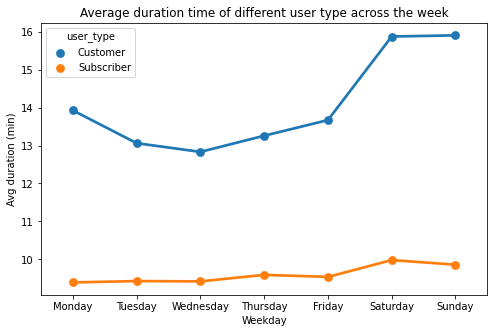